# Reproducible Research: Peer Assessment 1

## Loading and preprocessing the data

1. Read the data into a table, and explore the first rows

```r
activity<-read.csv("activity.csv")
head(activity)
```

```
##   steps       date interval
## 1    NA 2012-10-01        0
## 2    NA 2012-10-01        5
## 3    NA 2012-10-01       10
## 4    NA 2012-10-01       15
## 5    NA 2012-10-01       20
## 6    NA 2012-10-01       25
```

2. Coerce the data to a data frame

```r
activitydf<-as.data.frame(activity)
```

## What is mean total number of steps taken per day?

1. Total number of steps each day in the variable StepsDay, to be displayed. Then explore a summary of the data.

```r
StepsDay<-rowsum(activitydf$steps,activitydf$date)
StepsDay
```

```
##             [,1]
## 2012-10-01    NA
## 2012-10-02   126
## 2012-10-03 11352
## 2012-10-04 12116
## 2012-10-05 13294
## 2012-10-06 15420
## 2012-10-07 11015
## 2012-10-08    NA
## 2012-10-09 12811
## 2012-10-10  9900
## 2012-10-11 10304
## 2012-10-12 17382
## 2012-10-13 12426
## 2012-10-14 15098
## 2012-10-15 10139
## 2012-10-16 15084
## 2012-10-17 13452
## 2012-10-18 10056
## 2012-10-19 11829
## 2012-10-20 10395
## 2012-10-21  8821
## 2012-10-22 13460
## 2012-10-23  8918
## 2012-10-24  8355
## 2012-10-25  2492
## 2012-10-26  6778
## 2012-10-27 10119
## 2012-10-28 11458
## 2012-10-29  5018
## 2012-10-30  9819
## 2012-10-31 15414
## 2012-11-01    NA
## 2012-11-02 10600
## 2012-11-03 10571
## 2012-11-04    NA
## 2012-11-05 10439
## 2012-11-06  8334
## 2012-11-07 12883
## 2012-11-08  3219
## 2012-11-09    NA
## 2012-11-10    NA
## 2012-11-11 12608
## 2012-11-12 10765
## 2012-11-13  7336
## 2012-11-14    NA
## 2012-11-15    41
## 2012-11-16  5441
## 2012-11-17 14339
## 2012-11-18 15110
## 2012-11-19  8841
## 2012-11-20  4472
## 2012-11-21 12787
## 2012-11-22 20427
## 2012-11-23 21194
## 2012-11-24 14478
## 2012-11-25 11834
## 2012-11-26 11162
## 2012-11-27 13646
## 2012-11-28 10183
## 2012-11-29  7047
## 2012-11-30    NA
```

```r
summary(StepsDay)
```

```
##        V1
##  Min.   :   41
##  1st Qu.: 8841
##  Median :10765
##  Mean   :10766
##  3rd Qu.:13294
##  Max.   :21194
##  NA's   :8
```

2. Plot an histogram of the data

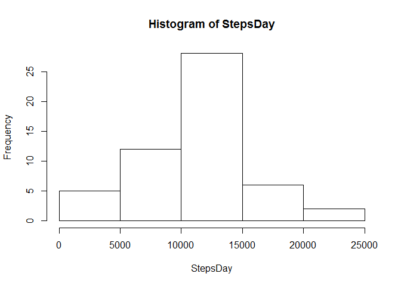

```r
hist(StepsDay)
```

3. Mean and median of the number of steps per day

```r
meanv<-round(mean(StepsDay, na.rm=TRUE),digits=0)
med<-median(StepsDay, na.rm=TRUE)
```

The mean number of steps per day rounded to the unit step is 10766, and the median number of steps per day is 10765

## What is the average daily activity pattern?

1. Plot of the average number of steps across all days per daily 5-min interval

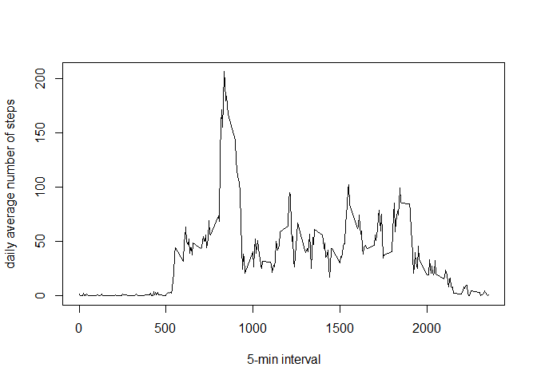

```r
pattern<-aggregate(activitydf$steps~activitydf$interval, FUN=mean)

plot(pattern, type="l", xlab="5-min interval", ylab="daily average number of steps")
```

2. The interval that contains the maximum average number of steps:

```r
imax<-which(pattern$`activitydf$steps` == max(pattern$`activitydf$steps`), arr.ind = TRUE)
maxintv<-pattern$`activitydf$interval`[imax]
```

It is 835

## Imputing missing values

1. Missing values in the dataset:

```r
s<-sum(is.na(activitydf))
```

The total number of missing values in the dataset is 2304.

2. A strategy for filling in all missing values in the dataset could be assigning the mean value of the variable where data is missing.
3. Creating a new dataset that is equal to the original dataset but with the missing data filled in

```r
library(imputeTS)
activitydf2<-activitydf
activitydf2<-na.mean(activitydf)
```

```r
StepsDay2<-rowsum(activitydf2$steps,activitydf2$date)
summary(StepsDay2)
```

```
##        V1
##  Min.   :   41
##  1st Qu.: 9819
##  Median :10766
##  Mean   :10766
##  3rd Qu.:12811
##  Max.   :21194
```

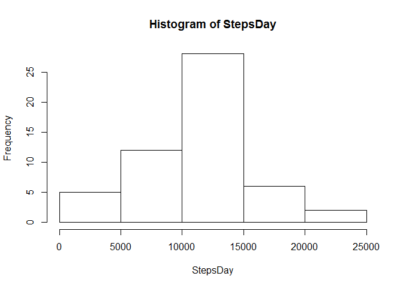

```r
hist(StepsDay)
```

Mean and median total number of steps taken per day.

```r
meanv2<-round(mean(StepsDay2, na.rm=TRUE),digits=0)
med2<-median(StepsDay2, na.rm=TRUE)
```

The mean number of steps per day rounded to the unit step is 10766, and the median number of steps per day is 10766.19

## Are there differences in activity patterns between weekdays and weekends?

1. To create a new factor variable in the dataset with two levels - “weekday” and “weekend” indicating whether a given date is a weekday or weekend day, first add the day-of-week column in english language:

```r
Sys.setlocale("LC_TIME", "English")
```

```
## [1] "English_United States.1252"
```

```r
activitydf2$day <- weekdays(as.Date(activitydf2$date), abbreviate=FALSE)
```

and then convert day-of-week column vales to Weekday or Weekend

```r
for (i in 1:length(activitydf2$day)){
if (activitydf2$day[i] == "Saturday" || activitydf2$day[i] == "Sunday"){
        activitydf2$day[i] <- "Weekend"
} else {
        activitydf2$day[i] <- "Weekday"
}
}
activitydf2$day<-as.factor(activitydf2$day)
```

2. Panel plot comparing weekends and wwekdays:

First, separate data for each

```r
X <- split(activitydf2, activitydf2$day)
d1<-as.data.frame(X[1])
d2<-as.data.frame(X[2])

names(d1)[1]<-paste("steps")
names(d1)[3]<-paste("interval")

names(d2)[1]<-paste("steps")
names(d2)[3]<-paste("interval")
```

Second, compute the relevant averages

```r
pat1<-aggregate(d1$steps~d1$interval, FUN=mean)
pat2<-aggregate(d2$steps~d2$interval, FUN=mean)
```

Panel plot of both segments

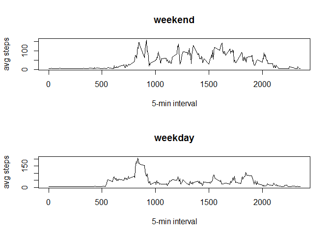

```r
par(mfrow=c(2,1))
plot(pat2, type="l", xlab="5-min interval", ylab="avg steps", main = "weekend")
plot(pat1, type="l", xlab="5-min interval", ylab="avg steps", main = "weekday")
```